# Project: Investigation of No-show appointments in Brazil

## Question 2

```python
# get counts for age_group
age_group_counts = df.groupby(['no_show', 'age_group']).count()['appointmentID']
age_group_counts
```

```
no_show  age_group
False    0-20         21852
         20-40        22209
         40-60        24490
         60-80        14373
         >80           2383
True     0-20          6455
         20-40         6624
         40-60         5591
         60-80         2537
         >80            468
Name: appointmentID, dtype: int64
```

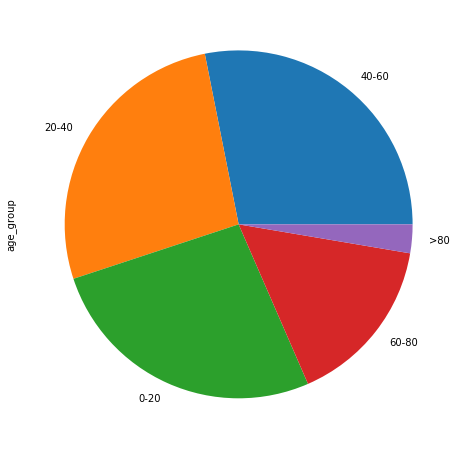

```python
df['age_group'].value_counts().plot(kind='pie', figsize=(8,8));

# More or less equal between amount of patients making appointments between 0-20, 20-40, 40-60.
# Over 60 make significantly less appts
```

## Question 3

```python
# get counts for disabailities vs no_show_group
disability_counts = df.groupby(['no_show', 'handicap']).count()['appointmentID']
disability_counts

# More people with disabilities showed up to their appts than no show
# They will most likely always be in the minority, so it's not a surprise
# It also doesn't give us any useful insight unless we know why they didn't show up eg. transport access
```

```
no_show  handicap
False    0           86373
         1            1676
         2             146
         3              10
         4               2
True     0           21909
         1             364
         2              37
         3               3
         4               1
Name: appointmentID, dtype: int64
```

## Question 4

```python
# get counts for gender vs no_show_group
gender_counts = df.groupby(['no_show', 'gender']).count()['appointmentID']
gender_counts

# About half the number of males than females in each group
# Gender doesn't tell us anything about being more likely to no show
```

```
no_show  gender
False    F         57245
         M         30962
True     F         14591
         M          7723
Name: appointmentID, dtype: int64
```

## Question 5

```python
# get counts for scholarship vs no_show_group
scholarship_counts = df.groupby(['no_show', 'scholarship']).count()['appointmentID']
scholarship_counts

# Around 10% of those that showed up had scholarships
# Around the same % for those with no shows
```

```
no_show  scholarship
False    False          79924
         True            8283
True     False          19736
         True            2578
Name: appointmentID, dtype: int64
```

## Question 6

```python
# get counts for neighbourhood
neighbourhood_counts = df.groupby(['no_show', 'neighbourhood']).count()['appointmentID']
neighbourhood_counts
```

```
no_show  neighbourhood
False    AEROPORTO                 7
         ANDORINHAS             1741
         ANTÔNIO HONÓRIO         221
         ARIOVALDO FAVALESSA     220
         BARRO VERMELHO          332
                                ...
True     SÃO JOSÉ                428
         SÃO PEDRO               515
         TABUAZEIRO              572
         UNIVERSITÁRIO            32
         VILA RUBIM              141
Name: appointmentID, Length: 160, dtype: int64
```

## Question 7

```python
# get counts for SMS_received vs no_show_group
SMS_received_counts = df.groupby(['no_show', 'SMS_received']).count()['appointmentID']
SMS_received_counts

# About 30% of those with appts got SMS
# 30% of those who shows up got an SMS
# 44% of those who didn't show up got an SMS
# When are they most likely to send SMS?
```

```
no_show  SMS_received
False    False           62509
         True            25698
True     False           12530
         True             9784
Name: appointmentID, dtype: int64
```

```python
# get counts for SMS_received vs no_show_group vs diff_days_group
SMS_received_2_counts = df.groupby(['no_show', 'diff_days_group','SMS_received']).count()['appointmentID']
SMS_received_2_counts

# No one who has same day appts gets an SMS
# No one who has appts made 1-2 days before gets an SMS
# Doesn't seem to affect whether you go or not for 3-4 day appt (roughly 50% in each group)
```

```
no_show  diff_days_group  SMS_received
False    0                False           36770
         1-2              False            9223
         11-30            False            6141
                          True            10152
         3-4              False            3071
                          True             3081
         5-10             False            4825
                          True             7991
         >30              False            2479
                          True             4474
True     0                False            1792
         1-2              False            2715
         11-30            False            3538
                          True             4237
         3-4              False             996
                          True              879
         5-10             False            2000
                          True             2732
         >30              False            1489
                          True             1936
Name: appointmentID, dtype: int64
```

# Exploratory Data Analysis

Dig further into the questions that had promise.

1. How time between making appt and scheduled day makes a difference to whether you show up or not

```python
# get total counts for each response
no_show_totals = df.groupby('no_show').count()['appointmentID']
no_show_totals

#110,521 appts
```

```
no_show
False    88207
True     22314
Name: appointmentID, dtype: int64
```

```python
# get proportions by dividing no_show counts by total # of appointments
no_show_proportions = diff_days_counts[True] / no_show_totals[True]
no_show_proportions

#This is the % of each diff_days group that did no_show
```

```
diff_days_group
0        0.080308
1-2      0.121672
11-30    0.348436
3-4      0.084028
5-10     0.212064
>30      0.153491
Name: appointmentID, dtype: float64
```

```python
# get proportions by dividing no_show counts by total # of appointments
show_proportions = diff_days_counts[False] / no_show_totals[False]
show_proportions

#This is the % of each diff_days group that showed up to their appt
```

```
diff_days_group
0        0.416860
1-2      0.104561
11-30    0.184713
3-4      0.069745
5-10     0.145295
>30      0.078826
Name: appointmentID, dtype: float64
```

```python
#Plot proportions on a bar chart Set the x coordinate location for each rating group and and width of each bar

ind = np.arange(len(no_show_proportions))  # the x locations for the groups
width = 0.35       # the width of the bars
```

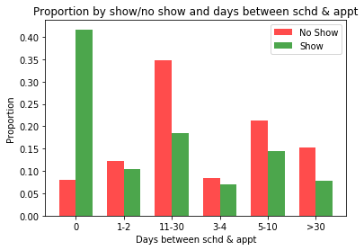

```python
# plot bars
red_bars = plt.bar(ind, no_show_proportions, width, color='r', alpha=.7, label='No Show')
green_bars = plt.bar(ind + width, show_proportions, width, color='g', alpha=.7, label='Show')

# title and labels
plt.ylabel('Proportion')
plt.xlabel('Days between schd & appt')
plt.title('Proportion by show/no show and days between schd & appt')
locations = ind + width / 2  # xtick locations
labels = ['0', '1-2', '11-30', '3-4', '5-10', '>30']  # xtick labels
plt.xticks(locations, labels)

# legend
plt.legend()
```

40% of appts kept are made on same day

Appts made 5 or more days in advance have more chance of being a no show

1. Does receiving an SMS help to prevent no show?

```python
import pandas as pd
import numpy as np
import matplotlib.pyplot as plt
%matplotlib inline

df = pd.read_csv('noshowscleanedv3.csv')
```

```python
# get counts for SMS_received vs no_show_group vs diff_days_group
SMS_received_3_counts = df.groupby(['SMS_received', 'diff_days_group','no_show']).count()['appointmentID']
SMS_received_3_counts
```

```
SMS_received  diff_days_group  no_show
False         0                False      36770
                               True        1792
              1-2              False       9223
                               True        2715
              11-30            False       6141
                               True        3538
              3-4              False       3071
                               True         996
              5-10             False       4825
                               True        2000
              >30              False       2479
                               True        1489
True          11-30            False      10152
                               True        4237
              3-4              False       3081
                               True         879
              5-10             False       7991
                               True        2732
              >30              False       4474
                               True        1936
Name: appointmentID, dtype: int64
```

```python
df_SMS_yes = df[df['SMS_received'] == True]
df_SMS_no = df[df['SMS_received'] == False]
```

```python
df_SMS_yes.to_csv('SMS_yes.csv', index=False)
```

```python
df_SMS_no.to_csv('SMS_no.csv', index=False)
```

```python
# get counts for no_show vs diff_days_group within SMS_yes
no_show_counts = df_SMS_yes.groupby(['no_show', 'diff_days_group']).count()['appointmentID']
no_show_counts
```

```
no_show  diff_days_group
False    11-30              10152
         3-4                 3081
         5-10                7991
         >30                 4474
True     11-30               4237
         3-4                  879
         5-10                2732
         >30                 1936
Name: appointmentID, dtype: int64
```

```python
# get total counts for each response
no_show_totals2 = df_SMS_yes.groupby('no_show').count()['appointmentID']
no_show_totals2
```

```
no_show
False    25698
True      9784
Name: appointmentID, dtype: int64
```

```python
# get proportions by dividing no_show counts by total # of appointments
no_show_true_proportions = no_show_counts[True] / no_show_totals2[True]
no_show_true_proportions
```

```
diff_days_group
11-30    0.433054
3-4      0.089841
5-10     0.279231
>30      0.197874
Name: appointmentID, dtype: float64
```

```python
# get proportions by dividing no_show counts by total # of appointments
no_show_false_proportions = no_show_counts[False] / no_show_totals2[False]
no_show_false_proportions
```

```
diff_days_group
11-30    0.395050
3-4      0.119893
5-10     0.310958
>30      0.174099
Name: appointmentID, dtype: float64
```

```python
#Plot proportions on a bar chart Set the x coordinate location for each rating group and and width of each bar

ind = np.arange(len(no_show_false_proportions))  # the x locations for the groups
width = 0.35       # the width of the bars
```

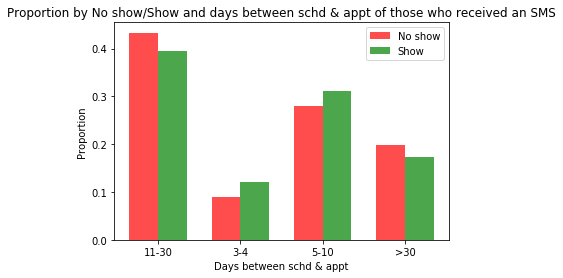

```python
# plot bars
red_bars = plt.bar(ind, no_show_true_proportions, width, color='r', alpha=.7, label='No show')
green_bars = plt.bar(ind + width, no_show_false_proportions.sort_index(axis=0), width, color='g', alpha=.7, label='Show')

# title and labels
plt.ylabel('Proportion')
plt.xlabel('Days between schd & appt')
plt.title('Proportion by No show/Show and days between schd & appt of those who received an SMS')
locations = ind + width / 2  # xtick locations
labels = ['11-30', '3-4', '5-10', '>30']  # xtick labels
plt.xticks(locations, labels)

# legend
plt.legend()
```

The graph shows that of those people who received an SMS, how many of them were no show/show and how many days did they have between making the appt and day of the apppointment.

No SMS were sent out for appointments made 2 days or less before.

If apppointments were made 3-4 or 5-10 days before and the person received an SMS, they were more likely to show up to their appointment.

If appointments were made 11-30 or more than 30 days before, even though they received an SMS, they were more likely to no show.

This suggests that sending an SMS is most effective for patients booking between 3-10 days before the scheduled date. Although, as we don't know when the SMS is sent, we can't make a comment on how many days before the appointment the SMS is most effective; this would require more data.

# Conclusion

After running the above analysis, we can deduce that the most interesting areas for further research would be time between making the appointment and the scheduled date and items such as age group and neighbourhood, which I did not look into in enough detail.

Since most appointments are made on the same day and this category has the least amount of no shows, we can guess that this type of appointment is urgent or highly needed.

Appointments made more than 5 days in advance is the key area for further research.

There are some limitations of this data, which could be improved for better analysis:

- We do not know when the SMS was sent, is that we cannot measure it's effectiveness in terms of reminding the patient to attend the appointment in terms of 'when is the best time to remind a patient?'.
- The data is also only collected over a few months in one year. If we had more months or years, we could observe patterns